# Diana Orazbek – MBA Portfolio

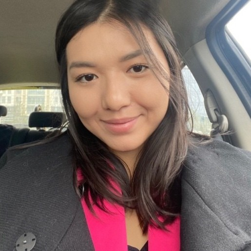

# Diana Orazbek

**MBA Candidate | Project Coordinator | Multilingual Business Professional**

## About Me

Hello everyone! My name is Diana. I am international student from Kazakhstan. I’m a results-driven Project Coordinator with over five years of experience spanning financial operations, business development, and cross-functional project support. Currently pursuing my MBA at University Canada West, I bring a global perspective shaped by my academic and professional background in both Kazakhstan and Canada. I thrive in fast-paced environments and am passionate about streamlining operations, building stakeholder relationships, and driving innovation.

## Education

**Master of Business Administration (MBA)**  
University Canada West, Vancouver, BC  
*Expected Graduation: 2025*

**Bachelor of Economics**  
Kazakh University of Economics, Kazakhstan

**Bachelor of Arts in Political Science & International Relations**  
Nazarbayev University, Kazakhstan

## Professional Experience

**Accounts Payable Clerk**  
*Quay Pacific Property Management, Vancouver, BC (Feb 2025 – Present)*  
- Manage monthly vendor payments and ensure 100% accuracy  
- Lead reconciliation efforts to improve financial reporting  
- Resolve billing issues across a multi-property portfolio

**Manager, Business Development & Innovation**  
*Transtelecom JSC, Kazakhstan (Oct 2020 – Dec 2021)*  
- Directed strategic partnerships with Plug and Play accelerator  
- Launched 3 new B2C services, contributing to revenue growth  
- Coordinated compliance and product development across teams

**Marketing & Business Development Specialist**  
*Cardiac Surgery Center JSC, Kazakhstan (Jan 2020 – May 2020)*  
- Executed campaigns that boosted patient engagement  
- Secured sponsorships that elevated the hospital’s profile

**Project Support Coordinator**  
*International Astana Airport / KazProject Alliance LLP (Jun 2016 – Jan 2020)*  
- Oversaw training for ground services during terminal launch  
- Supported EXPO 2017 logistics and operations  
- Wrote the airport’s first operational manual

## Skills & Strengths

- Project Coordination & Financial Operations
- Business Development & Innovation
- Vendor & Stakeholder Management
- Multilingual Communication (Kazakh, Russian, English)
- Microsoft Office Suite | CRM Tools

## Contact

📧 dianakt1206@gmail.com  
📍 Vancouver, BC  
📞 +1 778-288-0872  
🔗 [LinkedIn: dianaorazbek](https://www.linkedin.com/in/dianaorazbek/)  
📸 [Instagram: @Diana_kt](https://www.instagram.com/Diana_kt)